# Compras en línea antes y después de la pandemia - Presentación Final

Si no tiene alguno de estos paquetes, por favor instalarlos con el siguiente código:

```r
#install.packages('readr')
#install.packages('dplyr')
#install.packages('modeest')
```

### 1. **Introducción**

Las compras en línea, son una forma en la que no es necesario hacer contacto físico para poder adquirir un producto o servicio. Debido al inicio de la pandemia de la COVID-19, restricciones como el distanciamiento social obligatorio, cuarentena obligatoria y toque de queda, hicieron que las personas eviten hacer contacto física con la finalidad de evitar contraer el virus. Es por ello que este proyecto busca determinar cómo la pandemia afectó a las compras online en la comunidad UTEC.

### 2. **Importancia**

Mediante esta investigación podremos determinar cómo ha cambiado el modo adquirir distintos productos debido a la pandemia en la que estamos viviendo. Muchas empresas se han visto forzadas a buscar nuevas formas de vender sus productos, mientras que otras, convenientemente, ya venían ofreciendo un servicio que se acomoda perfectamente a la situación promoviendo su crecimiento acelerado.

### 3. **Objetivos**

- Encontrar si han aumentado o disminuido las compras en línea antes y durante la pandemia.
- Encontrar cuales son los negocios más afectados y beneficiados por la pandemia con respecto a las compras en línea.
- Reconocer si es que hay variaciones respecto al gasto relacionado a las compras en línea antes y durante la pandemia.
- Encontrar si el método de pago más popular ha cambiado debido a la pandemia.
- Analizar el cambio de la perspectiva general de las personas acerca de las compras en línea debido a la pandemia.
- Estimar parámetros de la población a través de la muestra.

### 4. **Factibilidad**

Las actvidades para el desarrollo de la investigación se realizó de acuerdo a las metas planteadas por el grupo por periodos de tiempo. Se hizo uso de un diagrama de Gantt para asignar los límites para completar una determinada tarea.

#### **Diagrama de Gantt diseñado por el grupo 5:**

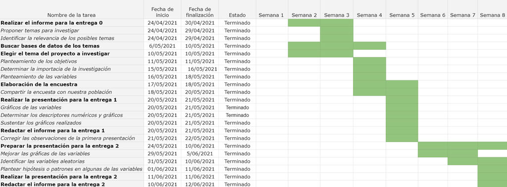

### 5. **Marco Teórico**

#### i) **Método de recolección de datos:**

Resumen de la base de datos proporcionado por R.

```
##  Marca temporal         Sexo                Edad         Ventaja
##  Length:199         Length:199         Min.   :16.00   Length:199
##  Class :character   Class :character   1st Qu.:18.00   Class :character
##  Mode  :character   Mode  :character   Median :18.00   Mode  :character
##                                        Mean   :21.34
##                                        3rd Qu.:20.00
##                                        Max.   :62.00
##  FrecuenciaAP        ProductoAP        DispositivoAP        CantidadAP
##  Length:199         Length:199         Length:199         Min.   : 0.000
##  Class :character   Class :character   Class :character   1st Qu.: 1.000
##  Mode  :character   Mode  :character   Mode  :character   Median : 3.000
##                                                           Mean   : 2.578
##                                                           3rd Qu.: 4.000
##                                                           Max.   :10.000
##     GastoAP     CantidadMesAP     GastoMesAP     MetodoPagaAP
##  Min.   :   0   Min.   : 0.00   Min.   :   0.0   Length:199
##  1st Qu.:  30   1st Qu.: 1.00   1st Qu.:  30.0   Class :character
##  Median :  50   Median : 3.00   Median :  60.0   Mode  :character
##  Mean   : 124   Mean   : 5.07   Mean   : 123.6
##  3rd Qu.: 100   3rd Qu.: 6.00   3rd Qu.: 150.0
##  Max.   :2500   Max.   :30.00   Max.   :1000.0
##  MomentoDiaAP          EscalaAP      FrecuenciaAC        ProductoAC
##  Length:199         Min.   : 1.000   Length:199         Length:199
##  Class :character   1st Qu.: 5.000   Class :character   Class :character
##  Mode  :character   Median : 7.000   Mode  :character   Mode  :character
##                     Mean   : 6.432
##                     3rd Qu.: 8.000
##                     Max.   :10.000
##  DispositivoAC        CantidadAC        GastoAC       CantidadMesAC
##  Length:199         Min.   :  0.00   Min.   :  0.00   Min.   : 0
##  Class :character   1st Qu.:  2.00   1st Qu.: 30.00   1st Qu.: 2
##  Mode  :character   Median :  3.00   Median : 50.00   Median : 4
##                     Mean   :  4.02   Mean   : 87.38   Mean   : 8
##                     3rd Qu.:  4.00   3rd Qu.:100.00   3rd Qu.:10
##                     Max.   :100.00   Max.   :600.00   Max.   :70
##    GastoMesAC    MetodoPagaAC       MomentoDiaAC          EscalaAc
##  Min.   :  0.0   Length:199         Length:199         Min.   : 1.000
##  1st Qu.: 70.0   Class :character   Class :character   1st Qu.: 7.000
##  Median :130.0   Mode  :character   Mode  :character   Median : 9.000
##  Mean   :200.9                                         Mean   : 8.025
##  3rd Qu.:300.0                                         3rd Qu.: 9.000
##  Max.   :800.0                                         Max.   :10.000
```

En donde se puede abstraer:

#### ii) **Variables**:

[output not shown]

#### iii) **Gráficos:**

##### **1. Gráfica de edades**

Para la variable Edad hemos considerado los descriptores numéricos media, mediana, moda y rango porque son los más relevantes para estudiar la variable edad. La media nos indica el valor promedio de la variable, la mediana el valor que se encuentra justo en la mitad, la moda es el valor que más se repite y el rango nos brinda el mínimo y máximo valor de la variable Edad.

Para esta variable, que es cuantitativa, se usó un histograma para poder separar los rangos de edades respecto a su frecuencia.

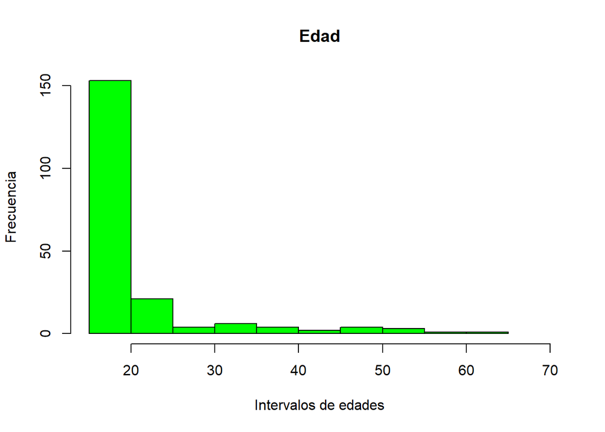

**Descriptores numéricos de Edad**

```
## [1] "La media es 21.3417085427136"
```

```
## [1] "La mediana es 18"
```

```
## [1] "La moda es 18"
```

```
## [1] "El rango es 16  y  62"
```

##### **2. Gráfica de género**

Para la variable Género observamos que nuestra muestra contiene más hombres que mujeres. En esta variable se usó un gráfico de barras (barplot) para diferenciar las proporciones entre hombre y mujeres, y se consideró a la moda como el único descriptor numérico relevante para el análisis de esta variable ya que, nos ayuda a comprobar que el género predominante en nuestra muestra es el masculino.

**Hipótesis:** Por lo observado en la Universidad creemos que la mayor parte de la muestra pertenecerá al género masculino.

**Patrón:** Como podemos ver, gracias a nuestro gráfico de barras y el resultado de la moda, concluimos que nuestra hipótesis es correcta diciéndonos que la mayor parte de nuestra muestra es masculino.

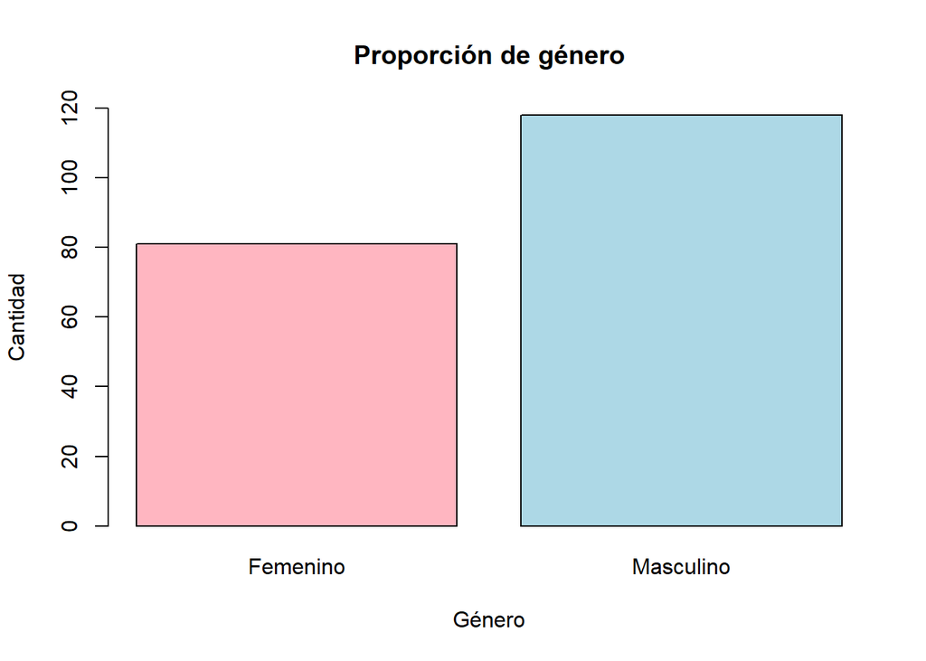

**Descriptores numéricos de Género**

```
## [1] "La moda es Masculino"
```

##### **3. Frecuencia de compras AP y AC**

Para la frecuencia de compra decidimos usar un gráfico de barras ya que, al ser una variable cualitativa, nos muestra claramente la popularidad de cada una de las opciones. Decidimos usar la moda ya que nos muestra la actitud más popular antes y después de la pandemia.

**Hipótesis:** Durante la pandemia, más personas van a empezar a usar la modalidad virtual debido a las restricciones para salir.

**Patrón:** Como podemos ver, la moda ha pasado de ser poco frecuente a regularmente lo cual demuestra que nuestra hipótesis era correcta. Además, las personas que nunca habían comprado se han reducido y las que compran más frecuentemente han incrementado, mostrando cómo la pandemia efectivamente ha aumentado la popularidad de las compras en línea.

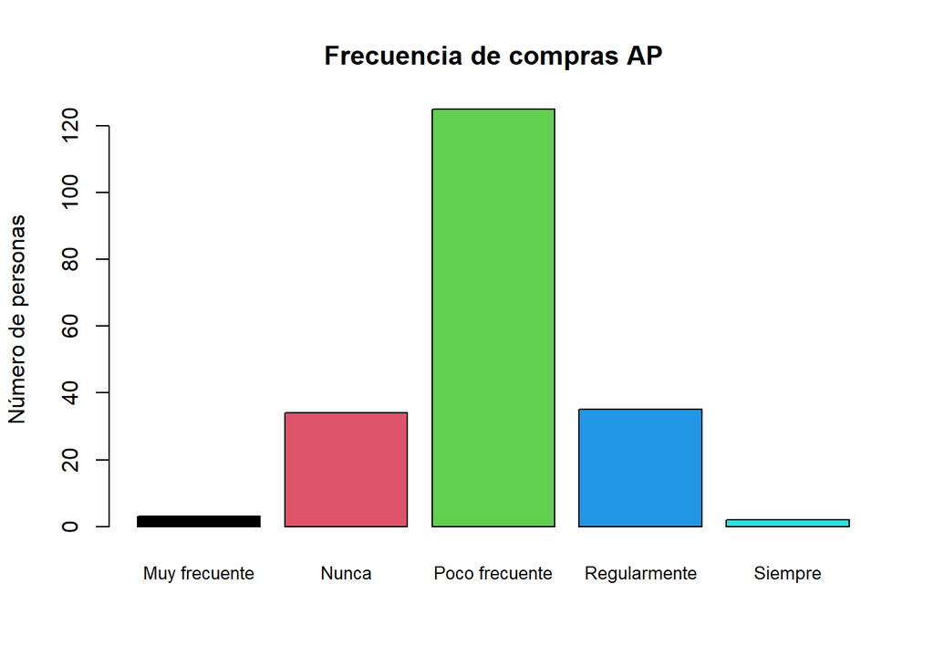

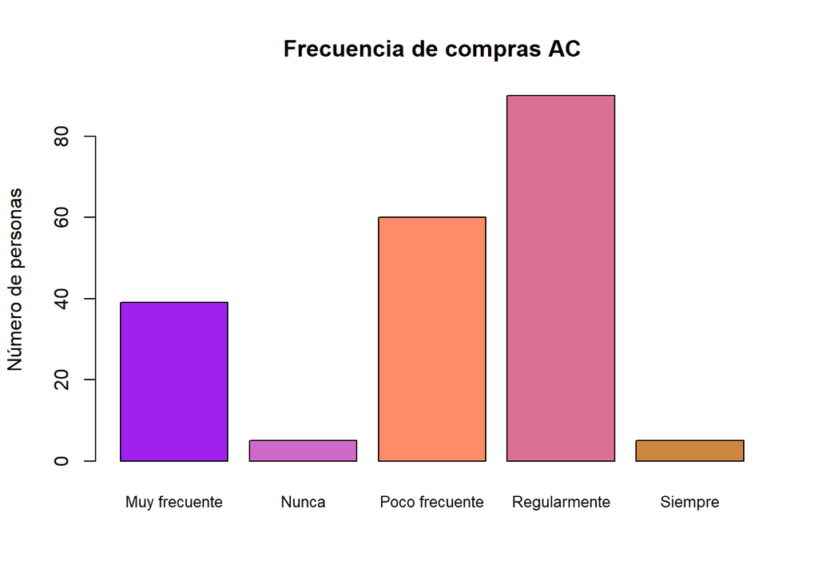

```
## [1] "La moda de la frecuencia de compras antes de la pandemia es  Poco frecuente"
```

```
## [1] "La moda de la frecuencia de compras actualmente es  Regularmente"
```

##### **4. Cantidad de productos por pedido AP y AC**

Ya que se trata de una variable numérica optamos por encontrar la media para saber la cantidad promedio de productos que se compraban antes de la pandemia y actualmente. La desviación estándar nos indica que tan dispersos se encuentran los valores respecto a la media de nuestra variable.

Decidimos usar un boxplot para estas variables para poder visualizar mejor la diferencia entre los rangos antes y después de pandemia y la cantidad de valores atípicos en ambos casos. Además de los descriptores numéricos que se pueden visualizar gracias a esta gráfica.

**Hipótesis:** Nosotros creemos que, debido a las ofertas y restricciones, las personas van a comprar más productos por compra.

**Patrón:** Como podemos ver, la mediana no ha cambiado antes de pandemia y actualmente, sin embargo, se puede observar en la segunda gráfica que las algunas personas han comenzado a adquirir una mayor cantidad de productos (datos atípicos) logrando alterar los valores de la media y la desviación estándar incrementándolos, lo cual nos muestra que el rango de productos que se compra ha incrementado y creemos que puede ser debido a las compras en línea de supermercados que tienen una alta cantidad de productos por pedido.

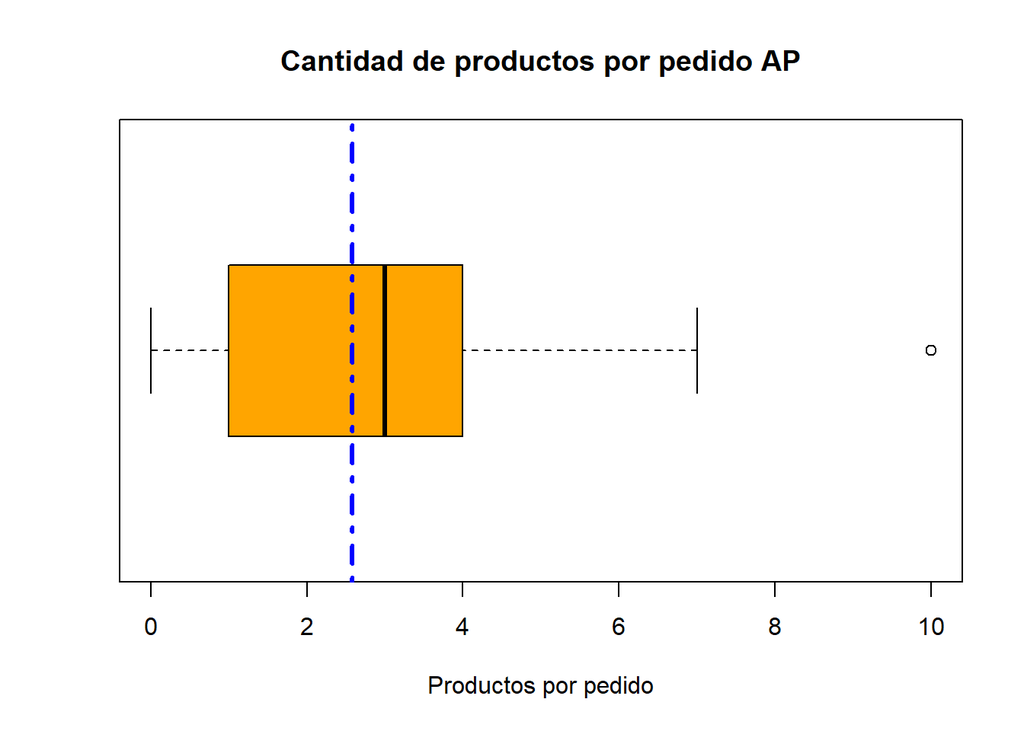

**Descriptores numéricos de Cantidad de productos por pedido AP**

```
## [1] "La media es 2.57788944723618"
```

```
## [1] "La mediana es 3"
```

```
## [1] "La moda es 3"
```

```
## [1] "La desviación estándar es  1.3565640831109"
```

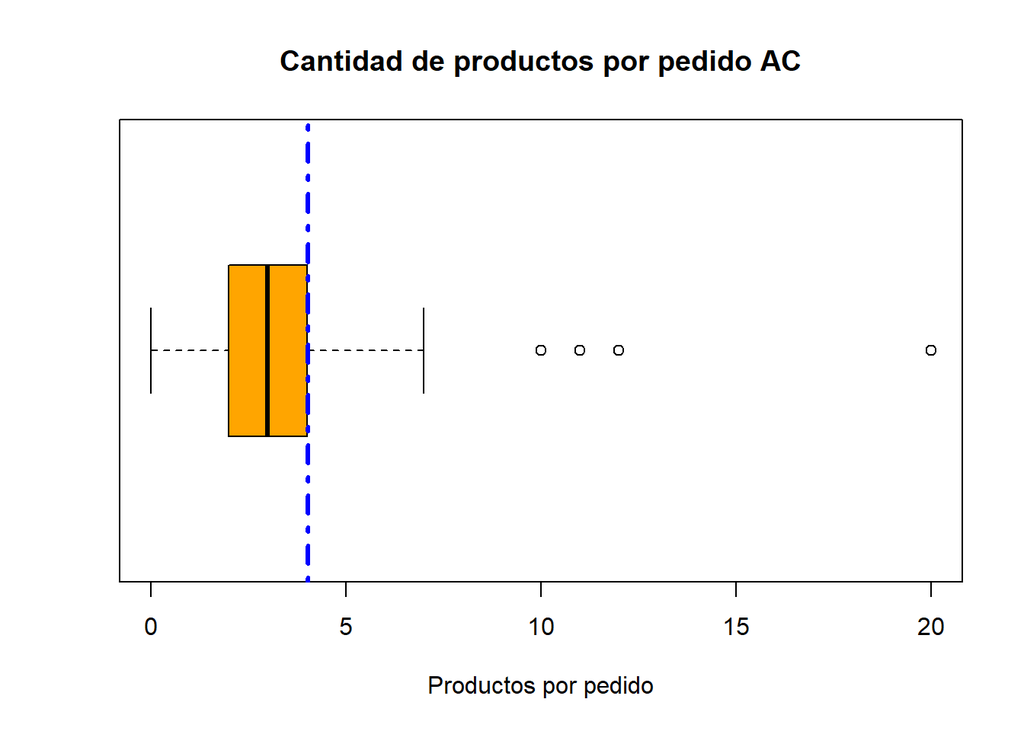

**Descriptores numéricos de Cantidad de productos por pedido AC**

```
## [1] "La media es 4.02010050251256"
```

```
## [1] "La mediana es 3"
```

```
## [1] "La moda es 2"
```

```
## [1] "La desviación estándar es  2.76553296030825"
```

##### **5. Cantidad de productos por mes AP y AC**

En este caso decidimos usar un gráfico de barras para representar la cantidad de productos por mes en ambos casos debido a que es una variable numérica discreta y podemos visualizar mediante este tipo de gráfico claramente la popularidad de cada una de las cantidades. Esto nos ayuda a comparar de manera fácil lo que se observa antes de la pandemia y actualmente.  
Se consideró la media y la mediana porque si el valor de la media es mayor al de la mediana se dice que la gráfica es sesgada a la derecha, lo cual se puede comprobar mediante los gráficos de barras. La moda nos indicará la cantidad de productos comprados que más se repite. La varianza nos indicará cómo es la variación de los datos.  
**Hipótesis:** Debido a la pandemia, la cantidad de productos por mes incrementará debido a las restricciones para salir y las ofertas que se ofrecen.  
**Patrón:** Como podemos observar, la cantidad de personas que no compraban antes ha disminuido bastante y la varianza es casi el doble, lo que sugiere que las personas compran más productos que antes y creemos que es debido a los supermercados, ya que ahora ofrecen servicios de compra en línea y, además, debido a que las personas piden más comida que antes.

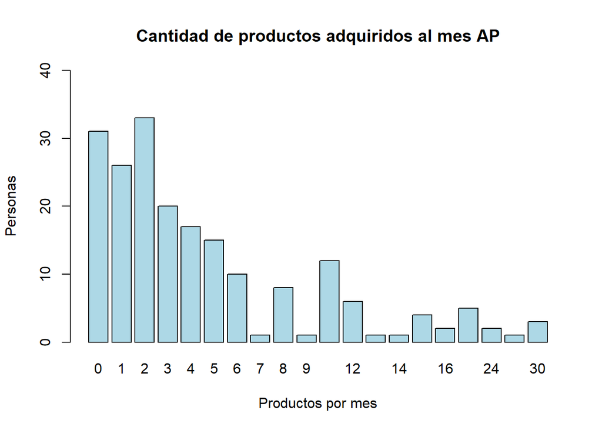

**Descriptores numéricos de Cantidad de productos adquiridos al mes AP**

```
## [1] "La media es  5.07035175879397"
```

```
## [1] "La mediana es  3"
```

```
## [1] "La moda es  2"
```

```
## [1] "La varianza es  6.02562502536856"
```

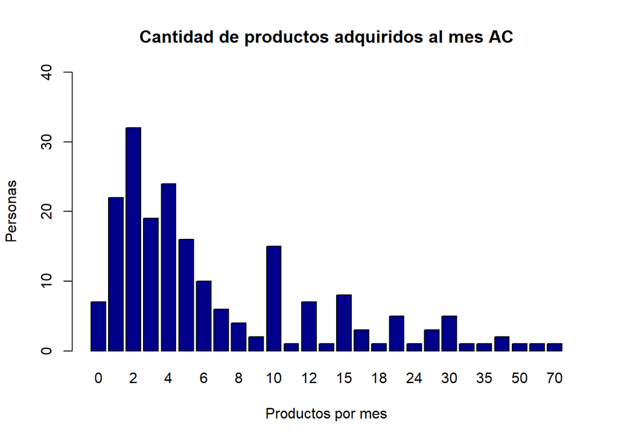

**Descriptores numéricos de Cantidad de productos adquiridos al mes AC**

```
## [1] "La media es  8"
```

```
## [1] "La mediana es  4"
```

```
## [1] "La moda es  2"
```

```
## [1] "La varianza es  10.1896164220388"
```

##### **6. Gastos por mes AP y AC**

El coeficiente de variabilidad nos indica al ver la variación que hay en los datos, que en este caso son de la variable Gasto aproximado antes de la pandemia y actualmente. Con ayuda del gráfico podemos verificar que la mayoría de los datos no se encuentran dispersos, es decir, el valor del coeficiente de variabilidad no debe ser muy grande. La mediana nos permite encontrar el valor del dato que se encuentra a la mitad. La media nos indica el gasto promedio antes de la pandemia y actualmente. **Hipótesis:** Antes de la pandemia la mayoría de personas gastaban muy poco en compras en línea por diversos motivos. En la actualidad, pensamos que habrá más personas que gasten una mayor cantidad de dinero en compras en línea comparado con la situación antes de la pandemia. **Patrón:** Pudimos concluir a partir de las gráficas que en la actualidad nuestra muestra presenta una menor cantidad de personas que su gasto aproximado es mínimo, concluyendo que las personas han comenzado a gastar un mayor monto en compras en línea.

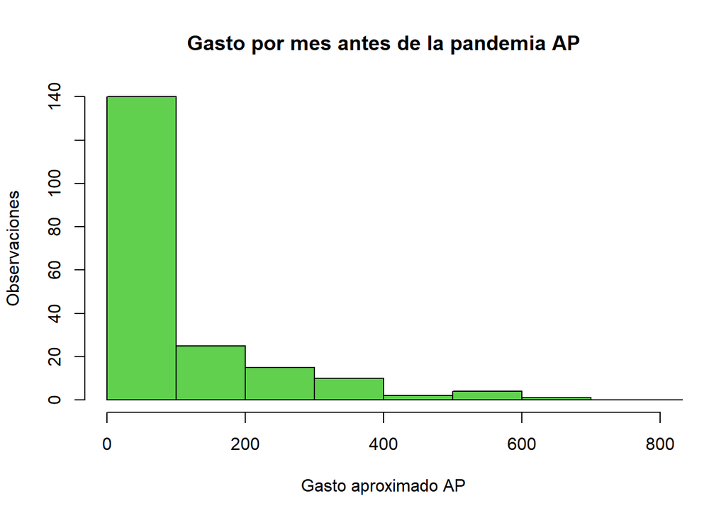

**Descriptores numéricos de Gastos por mes antes de la pandemia AP**

```
## [1] "La media es  123.613065326633"
```

```
## [1] "La mediana es  60"
```

```
## [1] "La moda es  0"
```

```
## [1] "El coeficiente de variacion es  0.102968027027453"
```

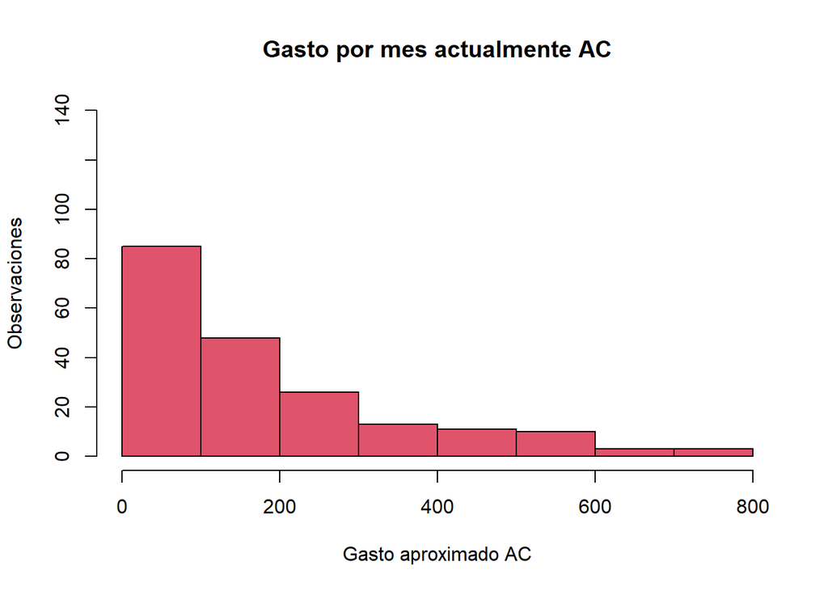

**Descriptores numéricos de Gastos por mes actualmente AC**

```
## [1] "La media es  200.884422110553"
```

```
## [1] "La mediana es  130"
```

```
## [1] "La moda es  100"
```

```
## [1] "El coeficiente de variacion es  0.0674415232231212"
```

##### **7. Producto más comprado AP y AC**

Decidimos usar un gráfico de barras ya que tenemos una variable cuantitativa con 5 opciones y esta gráfica representa claramente la popularidad de cada una de las opciones.

**Hipótesis:** Nosotros creemos que la comida va a ser uno de los productos que incrementará su popularidad y la cantidad de personas que no compran va a reducirse considerablemente.

**Patrones:** Como podemos ver, la cantidad de personas que compran comida ha incrementado y se mantiene como el producto más popular. Asimismo, la cantidad de personas que no compran se ha reducido mientras que la cantidad de personas que compran otros productos en línea ha incrementado. Esto posiblemente se debe a que muchos negocios que antes no funcionaban en línea, ahora han implementado este método de compra lo cual justificaría porque hay más productos calificados como “Otros” en nuestra data actualmente.

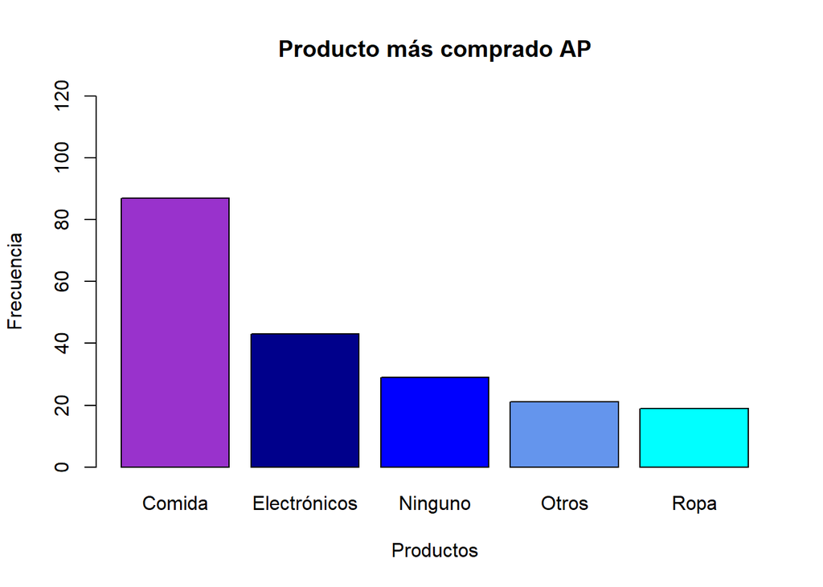

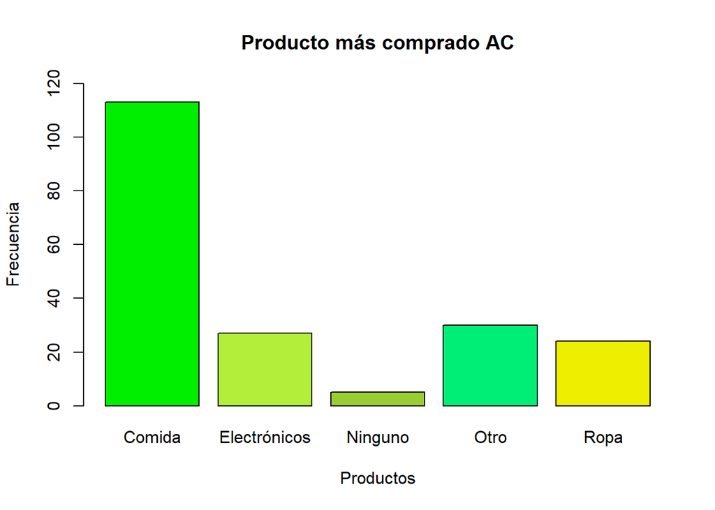

##### **8. Disposición a comprar en línea AP y AC**

Se decidió realizar un gráfico de barras para poder apreciar cuáles eran las disposiciones que fueron más escogidas por los encuestados. Además, observar si existe algún cambio en la disposición a comprar en línea de antes a después de la pandemia.

**Hipótesis:** En general sentimos que la disposición a comprar va a aumentar debido a las restricciones que trae la pandemia y también debido a la mejora de los servicios online de las empresas debido a la alta demanda que surgirá.

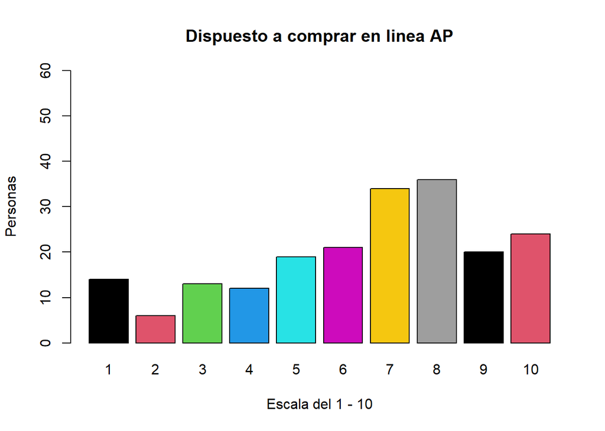

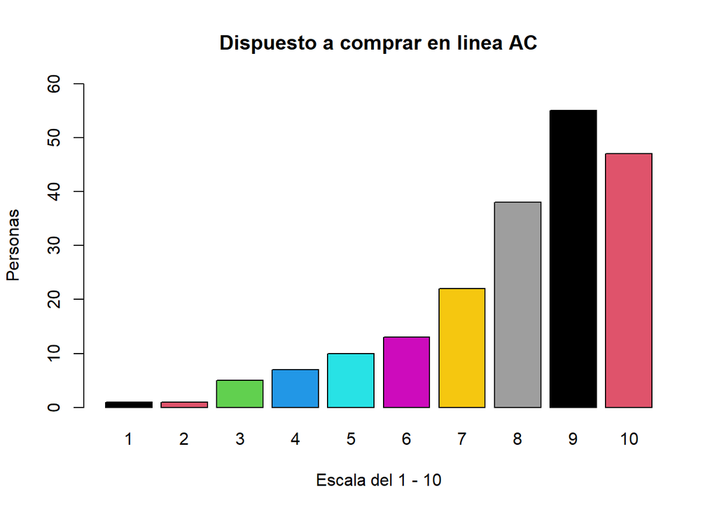

##### **9. Género - Edades**

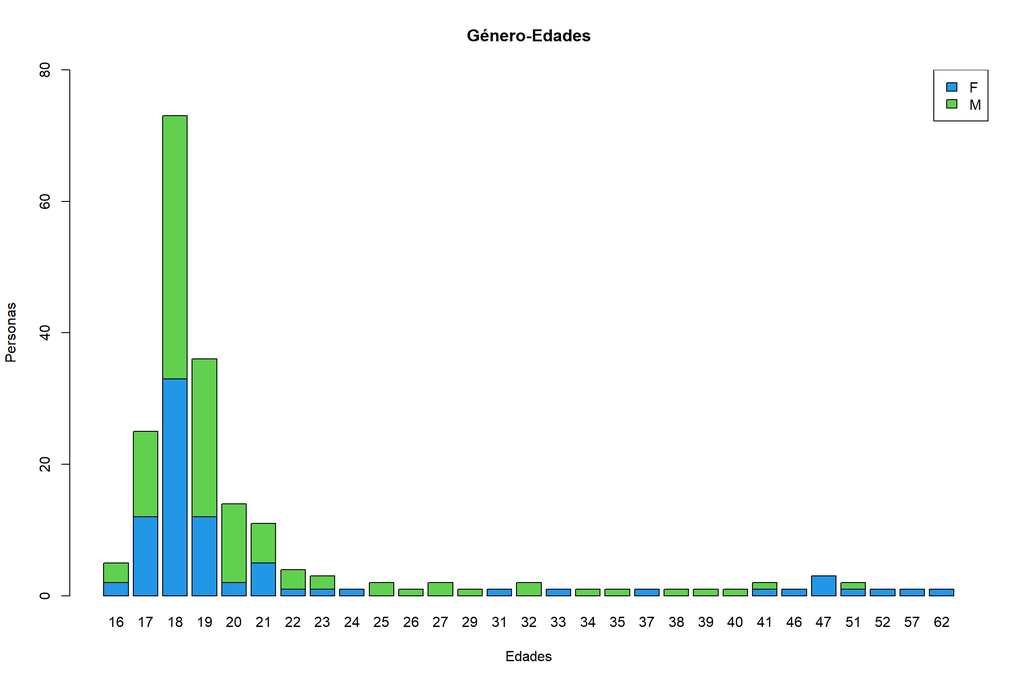

##### **10. Método de pago más popular - Producto más comprado (AP y AC)**

La gráfica nos muestra que los métodos de pago más frecuentes, efectivo y tarjeta, son usados mayormente para compras en línea relacionadas a la comida y electrónicos.

**Hipótesis:** Debido a la pandemia, el uso de tarjeta como método de pago se incrementa para evitar posibles contagios, y para evitar el contacto con otras personas los pedidos de comida se incrementarían.

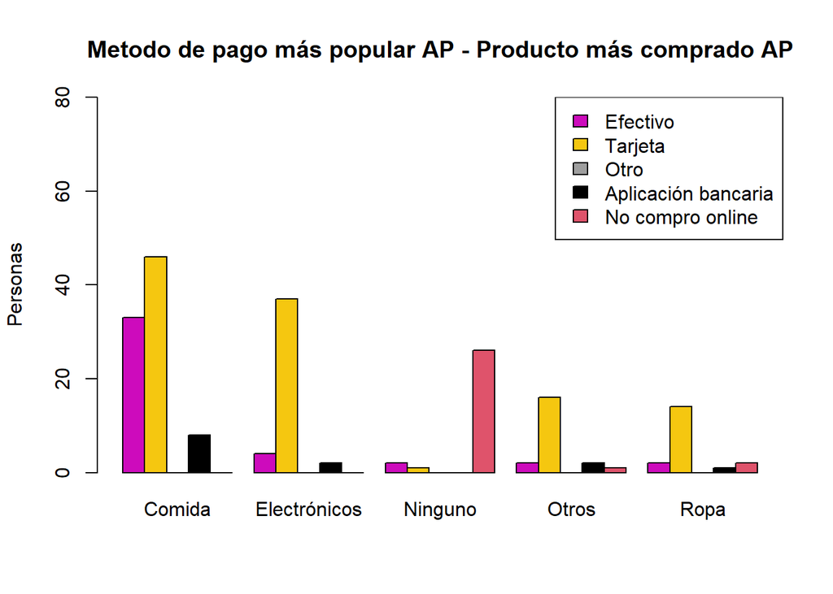

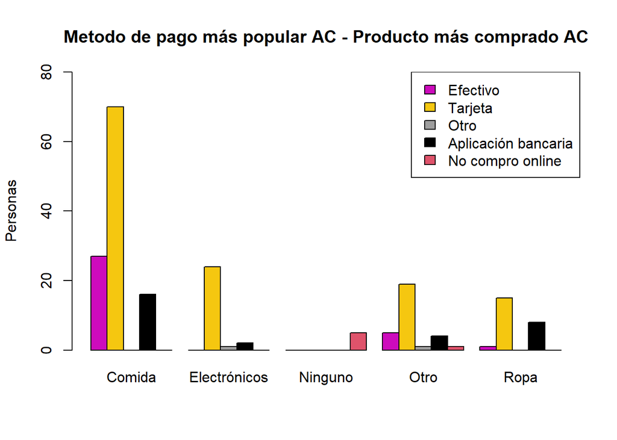

##### **11.Frecuencia de compra - Producto más comprado (AP y AC)**

Este tipo de gráfico lo hemos utilizado para poder representar mejor la distribución de los productos dependiendo de la frecuencia con la que compran las personas vía en línea.

**Hipótesis:** Nosotros creemos que gracias a la pandemia las frecuencias de compras incrementa, y a su vez las compras de necesidades básicas como comida tendrían el mismo comportamiento.

**Patrones:** Como podemos observar, los pedidos de comida siguen predominando ante los demás productos que las personas consumen. Además, las compras de comidas antes de la pandemia se consideraban dentro de las compras poco frecuentes. Sin embargo, en la actualidad las compras de comidas pasaron a ser muy frecuentes o de manera regular.

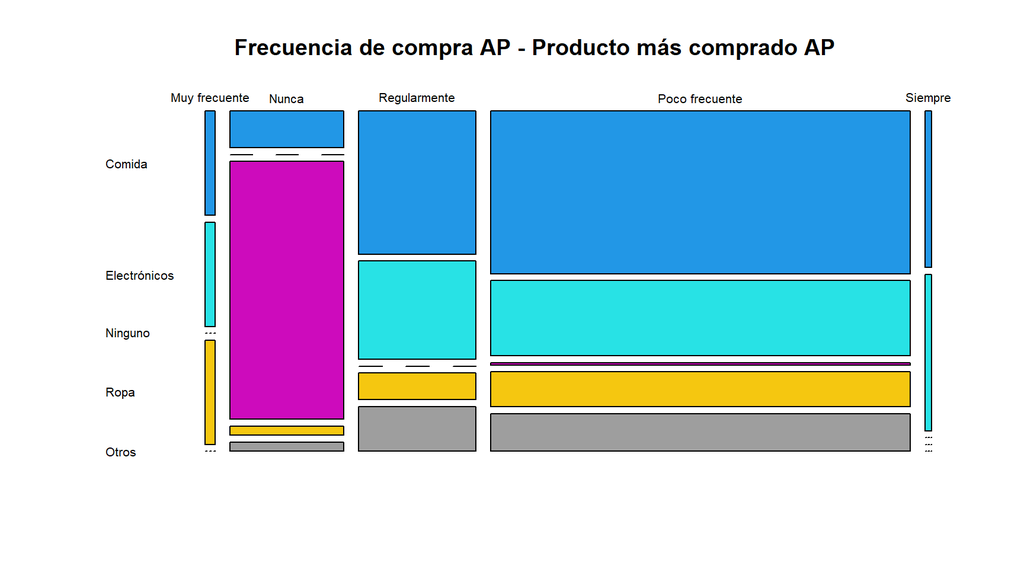

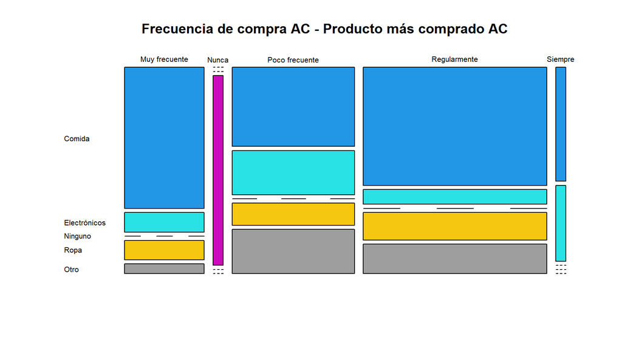

### **Variables aleatorias**

| Variable | Tipo | Distribución |
| --- | --- | --- |
| Cantidad de productos adquiridos AP y AC | V.A Discreta | Binomial |
| Edad | V.A Discreta | Binomial |
| Frecuencia de compra | V.A Discreta | Binomial |
| Gastos por mes AP y AC | V.A Continua | Normal |

### **Nivel de Confianza**

Las variables a analizar son:

##### **1. Producto más comprado AP y AC:**

Estas variables nos permitirán conocer, a través de proporciones, cuál el producto que más se compra en la comunidad UTEC. Para determinar el nivel de confianza de esta variable se consideró que la precisión sea alta debido a que, los datos no varían demasiado lo cual nos permite reducir el nivel de confianza para aumentar la precisión. El valor elegido para el nivel de confianza es 80%.

##### **2. Edad:**

Se eligió la variable Edad porque se desea conocer el promedio de edades de la comunidad UTEC. A causa de que el rango de esta variable va de 16 a 62 y se observa una gran dispersión en las edades, no podemos esperar una gran precisión, por ende, decidimos aumentar el nivel de confianza. El valor elegido para el nivel de confianza es 95% porque, si usamos valores más altos de confianza la zona de aceptación no varia mucho y tendríamos menor precisión, por esto, un valor central entre el nivel de confianza y precisión necesarios es el mencionado anteriormente.

### **Intervalos de Confianza**

Se utilizó el teorema del límite central para determinar los intervalos de confianza para la variables descritas anteriormente. Estos intervalos de confianza nos darán de resultado un rango, dependiendo del nivel de confianza usado, en el cual se espera que se encuentre el parámetro poblacional (media y proporciones de la población) de las variables edad, gasto por mes AC y AP, y producto más comprado AC y AP.

#### **a) Producto más comprado AP y AC**

El producto más comprado antes de la pandemia (AP) y actualmente (AC) es la variable comida. Se calculó la proporción de personas que comprarban comida para ambos casos, antes de la pandemia y actualmente. La propoción AP es 0.44 y AC es 0.58. Se determinaron los intevalos de confianza para la proporción con las fórmulas mostradas en clase.

#### Intervalo de confianza para el producto más comprado AP

El límite inferior es: 0.39  
El límite superior es: 0.49

#### Intervalo de confianza para el producto más comprado AC

El límite inferior es: 0.52  
El límite superior es: 0.62

#### Intervalo de confianza para la edad

El límite inferior es: 20.22  
El límite superior es: 22.46

#### Intervalo de confianza

El límite inferior es: 104.72  
El límite superior es: 142.50

#### Intervalo de confianza

El límite inferior es: 179.48  
El límite superior es: 222.29

### **Pruebas de Hipótesis**

#### **a) Producto más comprado AC**

El valor de la proporción para evaluar la hipótesis de 0.5 se determinó a partir de la proporción encontrada en la encuesta realizada, la cual es de 0.56. Además, en base a las gráficas descriptivas mostradas anteriormente acerca del producto mas comprado, se puedo inferir que la proporción de compra de productos actualmente, especialmente comida, aumenta.

- La hipótesis nula (H0) será que al menos el 50% de las personas consumían mayormente comida mediante compras en línea.
- La hipótesis alterna (H1) será que el porcentaje de las personas que consumían mayormente comida mediante compras en línea es menor al 50%.

$$H0: p >= 0.50$$
$$H1: p < 0.50$$

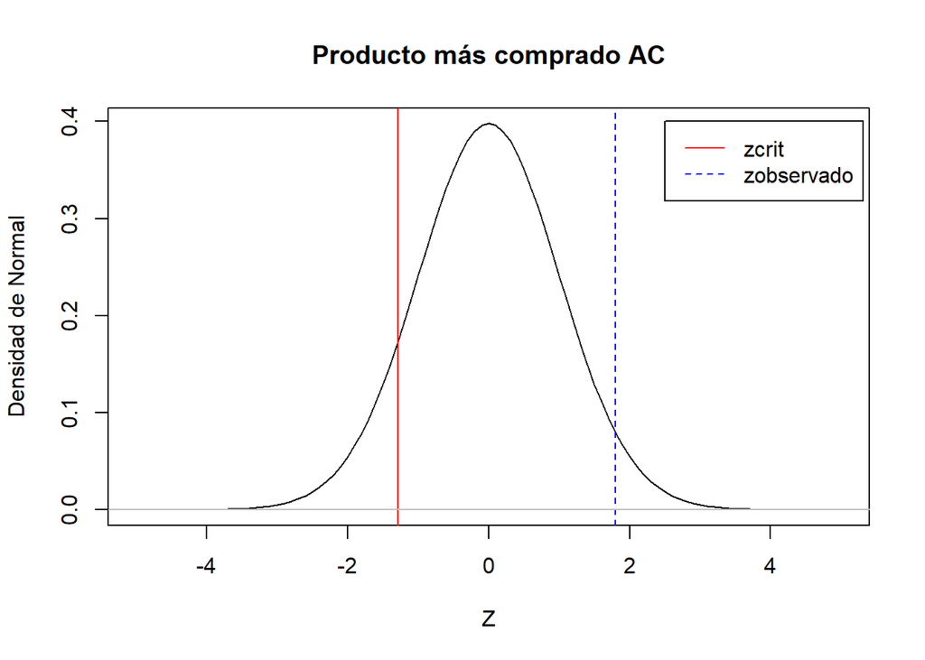

Como el Zobservado cae en la zona de aceptación, la hipótesis nula planteada anteriormente no se rechaza. Por lo tanto, al menos el 50% de las personas consumían mayormente comida mediante compras en línea.

#### **b) Producto más comprado AP**

- La hipótesis (H0) nula será que al menos el 40% de las personas consumían mayormente comida mediante compras en línea.
- La hipótesis alterna (H1) será que el porcentaje de las personas que consumían mayormente comida mediante compras en línea es menor al 40%.
  $$H0 : p >= 0.40$$
  $$H1 : p < 0.40$$

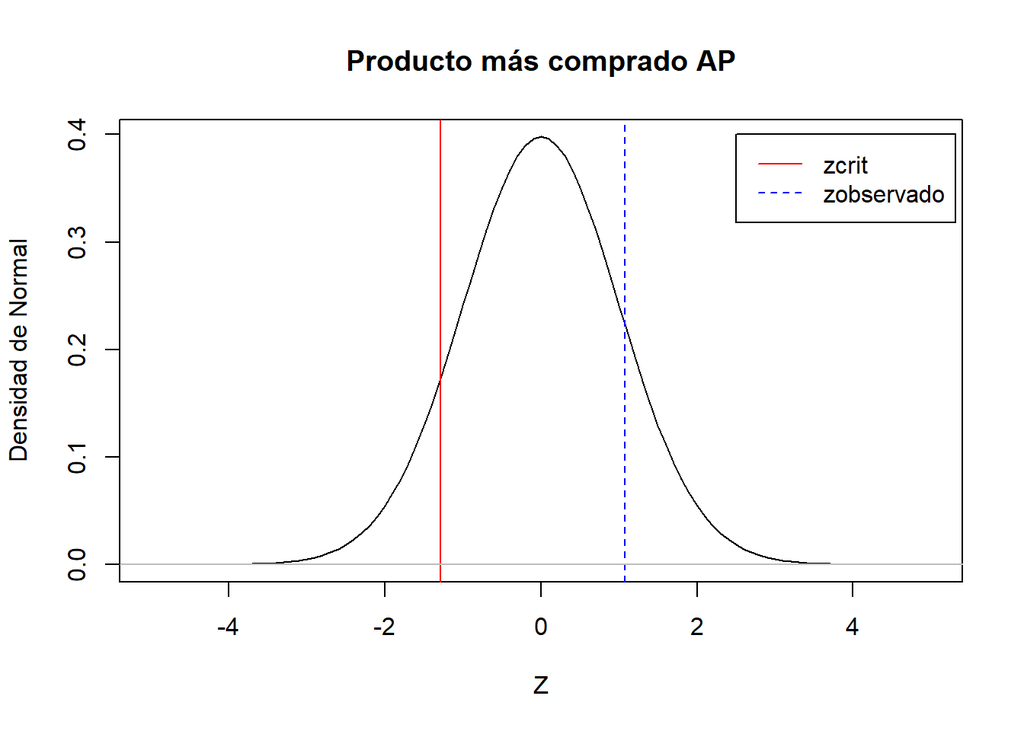

Como el Zobservado cae en la zona de aceptación, la hipótesis nula planteada anteriormente no se rechaza. Por esto, al menos el 40% de las personas consumían mayormente comida mediante compras en línea.

#### **c) Edad**

Elegimos esta hipótesis porque en el gráfico de barras que presentamos anteriormente se pudo observar que la proporción de personas que más respondieron nuestra encuesta tienen 18 años, por lo que suponemos que la media de la población podría ser igual al valor mencionado.

- La hipótesis nula (H0) será que la media de la edad es igual a 18 en la población estudiada.
- La hipótesis alterna (H1) será que la media de la edad es diferente de 18 en la población estudiada.
  $$H0: \mu =
  18$$
  $$H1: \mu ≠ 18$$

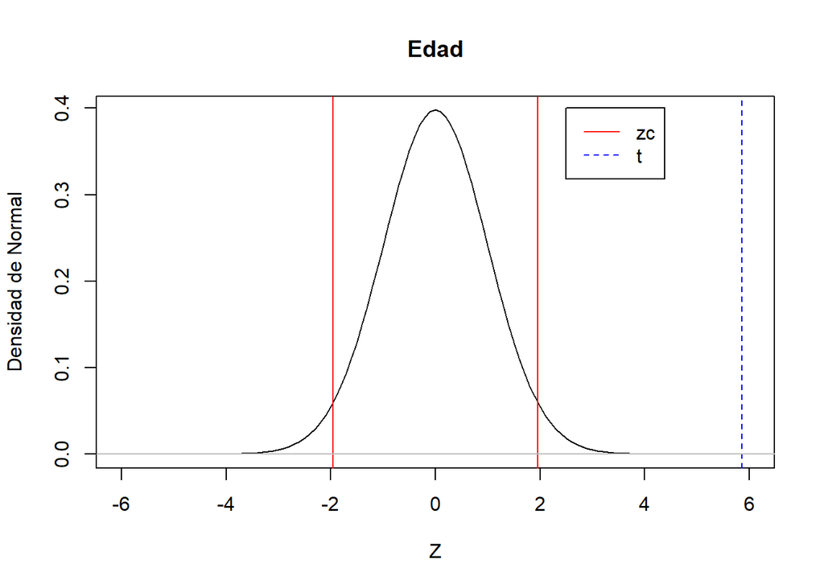

La hipótesis nula presentada se rechaza, porque el valor de t calculado no se encuentra en la zona de aceptación. Esto quiere decir que la media de la edad de nuestra población es diferente a 18 años.

#### **d) Gasto por mes AP**

Decidimos utilizar el valor de 130 soles porque es ligeramente mayor al de la muestra. Por las gráficas y descriptores numéricos vistos anteriormente la media de la muestra es aproximadamente 123.61, por esto, decidimos probar con un valor cerca, pero un poco más grande que el obtenido en la muestra.

- La hipótesis nula (H0) será que la media de los gastos por mes antes de la pandemia es menor o igual a 130 nuevos soles.
- La hipótesis alterna (H1) será que la media de los gastos por mes antes de la pandemia es mayor a 130 nuevos soles.
  $$H0: \mu <= 130$$
  $$H1: \mu > 130$$

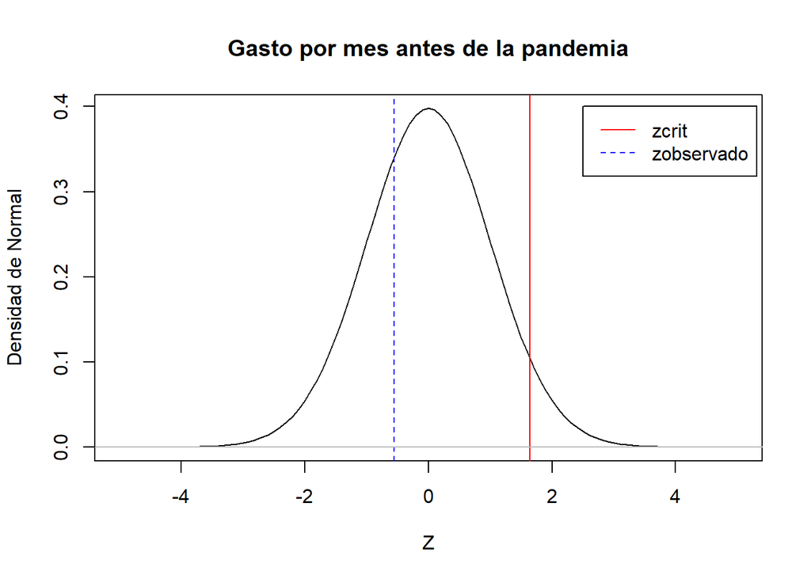

El valor de la hipótesis nula presentada anteriormente que es 130 cae en la zona de aceptación, por lo tanto no se rechaza. Esto quiere decir que la media de los gastos por mes antes de la pandemia es menor o igual a 130 nuevos soles.

#### **e) Gasto por mes AC**

Decidimos utilizar el valor de 210 soles porque es ligeramente mayor al de la muestra. Además, por las gráficas descriptivas anteriores vemos que las compras en línea aumentaron, por lo tanto, la media poblacional de la variable superará el valor de la media muestral.

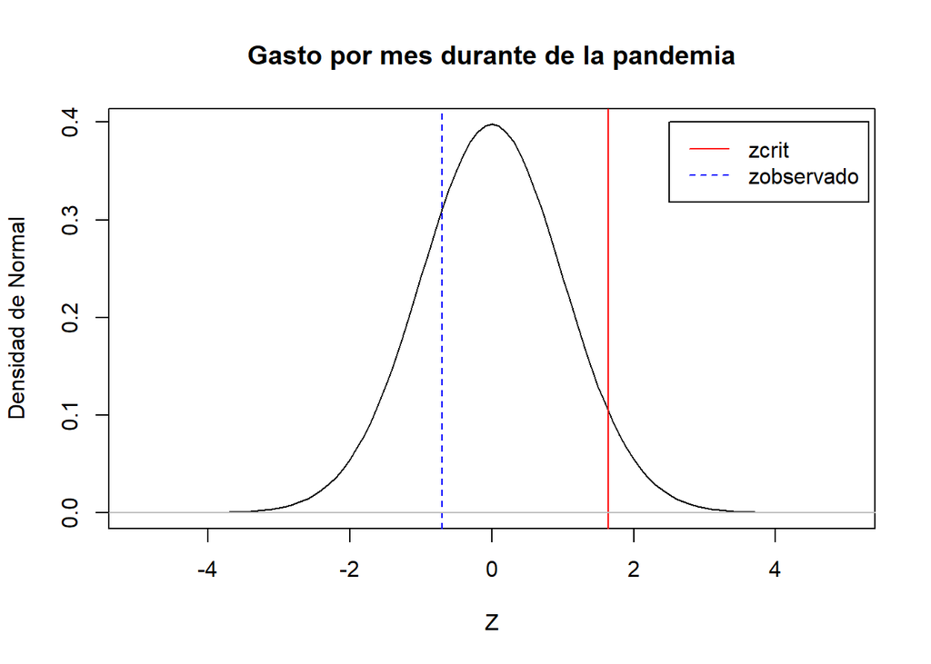

### **Regresión**

Utilizamos regresión lineal simple para relacionar cantidad de productos comprados por mes antes de la pandemia y actualmente con gasto aproximado por mes. Al realizar nuestra encuesta no especificamos el tipo de producto y por ello las variables utilizadas contienen datos que aplican a un rango amplio de productos lo cual lleva a una alta dispersión de los datos al realizar las gráficas. Sin embargo, se observa cierta relación lineal positiva y por ello decidimos usar regresión lineal. Las ecuaciones de regresión obtenidas para antes y durante la pandemia son: y=12.07x+62.44 y 7.88x+137.82 con un valor de r2 de 0.1973 y 0.1874 respectivamente. Los valores de r2 son muy bajos, debido a la alta dispersión de datos y la naturaleza de las variables previamente mencionado, lo cual nos indica que estas no son buenas funciones para aproximar los datos. A pesar de esto, se observa una relación entre ambas variables que tiene sentido, pero es afectada por fallas a la hora de diseñar la encuesta.

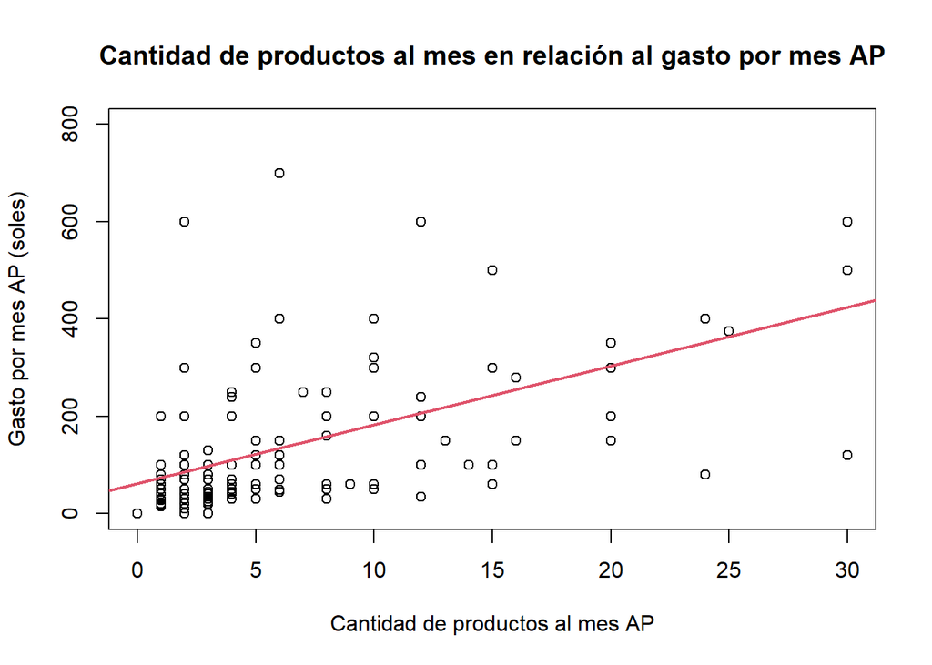

```
##      (Intercept) DF$CantidadMesAP
##         62.43860         12.06513
```

El dominio para el cual consideramos que aplica esta regresión es de 0 a 30.

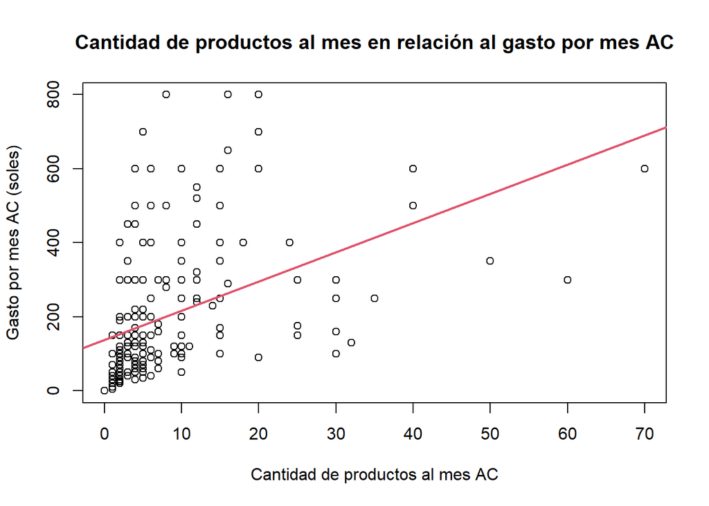

```
##      (Intercept) DF$CantidadMesAC
##       137.820311         7.883014
```

El dominio para el cual consideramos que aplica esta regresión es de 0 a 40.

Nos pareció interesante utilizar regresión para estimar cuanto gastaba una persona antes de la pandemia usando el gasto por mes actual. Nuevamente la alta dispersión de los datos se debe a una falla en nuestra encuesta ya que no especificamos el tipo de producto para el gasto por mes y estos valores de gasto varían debido al amplio rango de productos que se pudieron haber comprado. En la gráfica vemos una relación positiva débil con la siguiente ecuación: 0.52x+20.06 y un coeficiente de determinación de 0.34. Concluimos que este modelo no es realmente bueno para estimar el gasto por mes antes de la pandemia debido al bajo coeficiente de determinación y la naturaleza impredecible de ambas variables. Sin embargo, la relación mostrada resulta interesante para comparar los gastos antes y durante la pandemia.

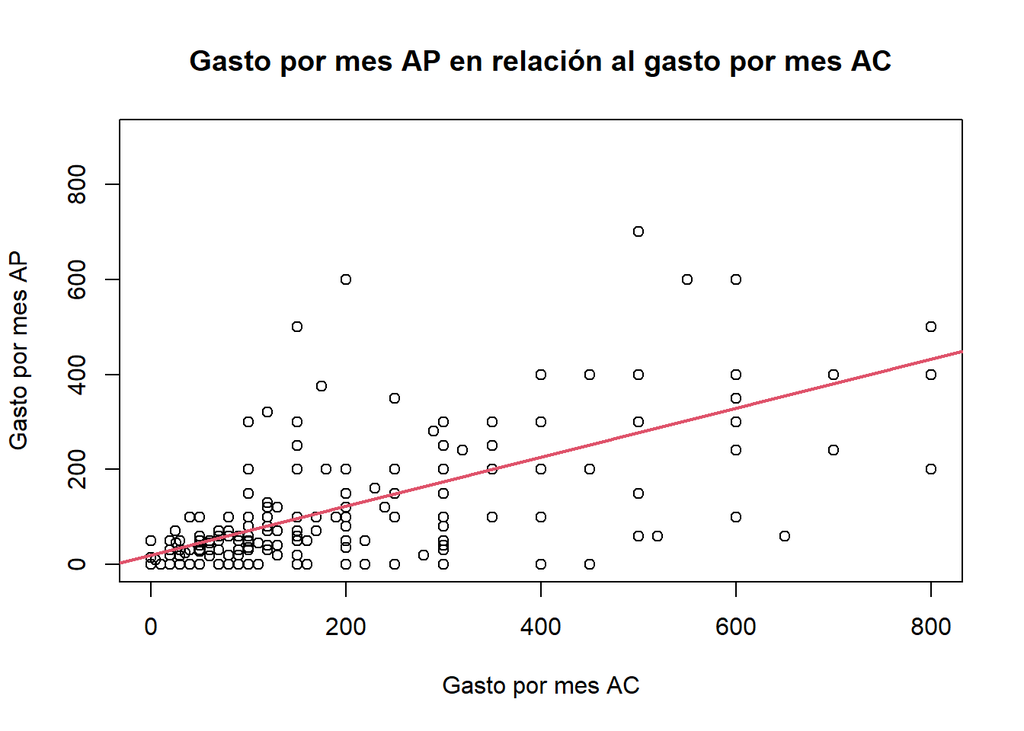

```
##   (Intercept) DF$GastoMesAC
##    20.0601312     0.5154851
```

El dominio para el cual consideramos que aplica esta regresión es de 0 a 800.

### 6. **Conclusiones**

- La cantidad de personas que compra en línea ha aumentado durante la pandemia.
- Las empresas que brindan servicio de comida a domicilio han sido los más beneficiados.
- El gasto aproximado en compras en línea ha incrementado durante la pandemia.
- Los métodos de pago que evitan el contacto entre personas se han vuelto más populares.
- En la actualidad las personas están más dispuestas a realizar compras el línea.

### 7. **Recomendaciones**

- Contar con más variables numéricas con la finalidad de poder encontrar más modelos de regresión lineal simple que explicarían el comportamiento de estas, teniendo en cuenta el coeficiente de determinación de cada una de ellas.
- Al momento de obtener la base de datos, especificar de manera adecuada las preguntas dentro de la encuesta.
- Es preferible contar con más observaciones para que la estimación de la media y proporción poblacional sean más cercanos al verdadero.